# Car Prices for Chevrolet Vehicles

## Background

Are you a Chevy fan or would you like to see Chevy data? I have done an analysis on the car make that most people know of, which is Chevrolet. I decided to conduct a two-lines linear regression analysis on Chevrolet vehicles to see if mileage, and whether the car has leather or not, significantly influences the price of the vehicle.

## The Comparison

As mentioned previously, the comparison that I am making is of Chevy vehicles that have leather seats and those that do not. I want to see if leather and mileage of Chevy vehicles are significant in predicting the price of the vehicle. I know that mileage is significant, but I do not know by how much so this test will help out with that. As mentioned previously, this will be a two-lines linear regression analysis.

## The Data

This data was previously collected data from the CarPrices.csv file. Therefore, none of it is data I collected. However, we have to use this data to perform a two-lines linear regression analysis. I am showing you the data after I filtered it to show only data for Chevy vehicles and the data I am making it show is the price, mileage, and whether the Chevy vehicle has leather seats or not. A “0” means that the Chevy vehicle does not have leather seats. A “1” means the Chevy vehicle has leather seats.

```r
datatable(Chevy, options=list(lengthMenu = c(20,20,20,20,20,20,20,20,20,20,20,20,20,20,20,20)), extensions="Responsive")
```

|  | Price | Mileage | Make | Leather |
| --- | --- | --- | --- | --- |
| 1 | 12146.18803 | 10011 | Chevrolet | 1 |
| 2 | 12163.82042 | 12101 | Chevrolet | 1 |
| 3 | 11472.02276 | 19699 | Chevrolet | 1 |
| 4 | 11017.16871 | 20100 | Chevrolet | 0 |
| 5 | 11096.85727 | 20334 | Chevrolet | 0 |
| 6 | 10386.04022 | 22225 | Chevrolet | 0 |
| 7 | 11137.04565 | 22484 | Chevrolet | 1 |
| 8 | 11045.10884 | 24568 | Chevrolet | 1 |
| 9 | 10777.05254 | 27906 | Chevrolet | 0 |
| 10 | 9928.188175 | 29680 | Chevrolet | 1 |

[output cut: 310 more lines]

## The Model

$$\underbrace{Y_i}_{\text{Price}} = \overbrace{\beta_0 + \beta_1 \underbrace{X_{i1}}_{\text{Mileage}}}^{\text{Chevy Vehicles}} + \overbrace{\beta_2 \underbrace{X_{i2}}_{\text{1= leather seats}} + \beta_3 \underbrace{X_{i1} X_{i2}}_{\text{Interaction}}}^{\text{Chevy Vehicles With Leather Seats}} + \epsilon_i$$

Here is the multiple linear regression model of what was previously explained.

| Type of Seats | Value of $X_{i2}$ | Resulting Model |
| --- | --- | --- |
| Non-leather | $X_{i2} = 0$ | $Y_i = \beta_0 + \beta_1 X_{i1} + \epsilon_i$ |
| Leather | $X_{i2} = 1$ | $Y_i = (\beta_0 + \beta_2) + (\beta_1 + \beta_3) X_{i1} + \epsilon_i$ |

## Test for Equal y-Intercepts

$$H_0: \beta_2 = 0 \quad \text{(Equal average starting cost for leather and non-leather Chevy's)} \\
H_a: \beta_2 \neq 0 \quad \text{(Non-equal average starting cost for leather and non-leather Chevy's)}$$

The null hypothesis for my test for equal Y-intercepts is saying that the average starting cost of a new Chevrolet vehicle with or without leather seats will be equal. The alternative hypothesis is saying that they will not be equal.

## Test for Equal slopes

$$H_0: \beta_3 = 0 \quad \text{(Equal rates of depreciation for leather and non-leather Chevy's)} \\
H_a: \beta_3 \neq 0 \quad \text{(Non-equal rates of depreciation for leather and non-leather Chevy's)}$$

The null hypothesis for my test for equal slopes is saying that there will be equal rates of depreciation for leather and non-leather Chevrolet vehicles. The alternative hypothesis is saying that there will not be equal rates of depreciation for leather and non-leather Chevrolet vehicles.

### Level of Significance

The level of significance for both of my hypotheses will be: $\alpha=0.05$

## The Results

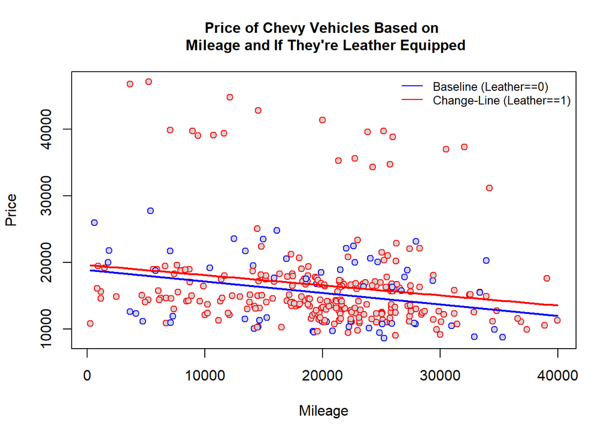

```r
Chevy_lm1 <- lm(Price ~ Mileage + Leather + Mileage:Leather, data=Chevy)

plot(Price ~ Mileage, data=Chevy, col=c("blue","red")[as.factor(Leather)], pch=21, bg="gray83", main="Price of Chevy Vehicles Based on \n Mileage and If They're Leather Equipped", cex.main=1)

legend("topright", legend=c("Baseline (Leather==0)", "Change-Line (Leather==1)"), bty="n", lty=1, col=c("blue","red"), cex=0.8)

#get the "Estimates" automatically:
b <- coef(Chevy_lm1)
# Then b will have 4 estimates:
# b[1] is the estimate of beta_0: -9.0099
# b[2] is the estimate of beta_1:  1.4385
# b[3] is the estimate of beta_2: -14.5107
# b[4] is the estimate of beta_3: 1.3214
curve(b[1] + b[2]*x, col="blue", lwd=2, add=TRUE)  #baseline (in blue)
curve((b[1] + b[3]) + (b[2] + b[4])*x, col="red", lwd=2, add=TRUE) #changed line (in red)
```

```r
summary(Chevy_lm1) %>%
  pander()
```

|  | Estimate | Std. Error | t value | Pr(>\|t\|) |
| --- | --- | --- | --- | --- |
| **(Intercept)** | 18901 | 2054 | 9.201 | 4.961e-18 |
| **Mileage** | -0.1721 | 0.09742 | -1.766 | 0.0783 |
| **Leather** | 721.7 | 2343 | 0.308 | 0.7583 |
| **Mileage:Leather** | 0.02028 | 0.1108 | 0.183 | 0.8549 |

Fitting linear model: Price ~ Mileage + Leather + Mileage:Leather

| Observations | Residual Std. Error | $R^2$ | Adjusted $R^2$ |
| --- | --- | --- | --- |
| 320 | 6801 | 0.03791 | 0.02878 |

The Y-intercept for the baseline is $\beta_0$, the mileage is the slope for the baseline and it’s represented by $\beta_1$. Leather is the Y-intercept for the change-line and is represented by $\beta_2$. Mileage:Leather is the slope for the change-line and is represented by $\beta_3$. $\beta_0$, $\beta_1$, $\beta_2$, and $\beta_3$ are all coefficient estimates. If we just look at the graphical summary, we see a slight difference in price when we compare Chevy vehicles that have leather seats vs Chevy vehicles that do not have leather seats. However, this difference does not look like much since both linear regressions are very close to each other.

If we look at the summary, the coefficient estimate for the baseline Y-intercept is significant. The baseline Y-intercept is telling us the price of a Chevy vehicle without miles and without leather seats. The coefficient estimate for the baseline slope is not significant. This is mileage. What this is saying is that for every mile, the price of a Chevy vehicle without leather seats decreases by $-0.1721.

Because mileage, leather, and the interaction between mileage and leather is not significant we have to remove the one that has the highest p-value. In this case, that is the mileage:leather interaction.

```r
Chevy_lm2 <- lm(Price ~ Mileage + Leather, data=Chevy)

summary(Chevy_lm2) %>%
  pander()
```

|  | Estimate | Std. Error | t value | Pr(>\|t\|) |
| --- | --- | --- | --- | --- |
| **(Intercept)** | 18602 | 1241 | 14.99 | 9.188e-39 |
| **Mileage** | -0.1564 | 0.04637 | -3.373 | 0.0008358 |
| **Leather** | 1112 | 967 | 1.15 | 0.251 |

Fitting linear model: Price ~ Mileage + Leather

| Observations | Residual Std. Error | $R^2$ | Adjusted $R^2$ |
| --- | --- | --- | --- |
| 320 | 6791 | 0.03781 | 0.03174 |

After taking off the mileage:leather interaction, mileage is finally significant, which it should be. However, I noticed that leather was still not significant. Therefore, I have to take it off.

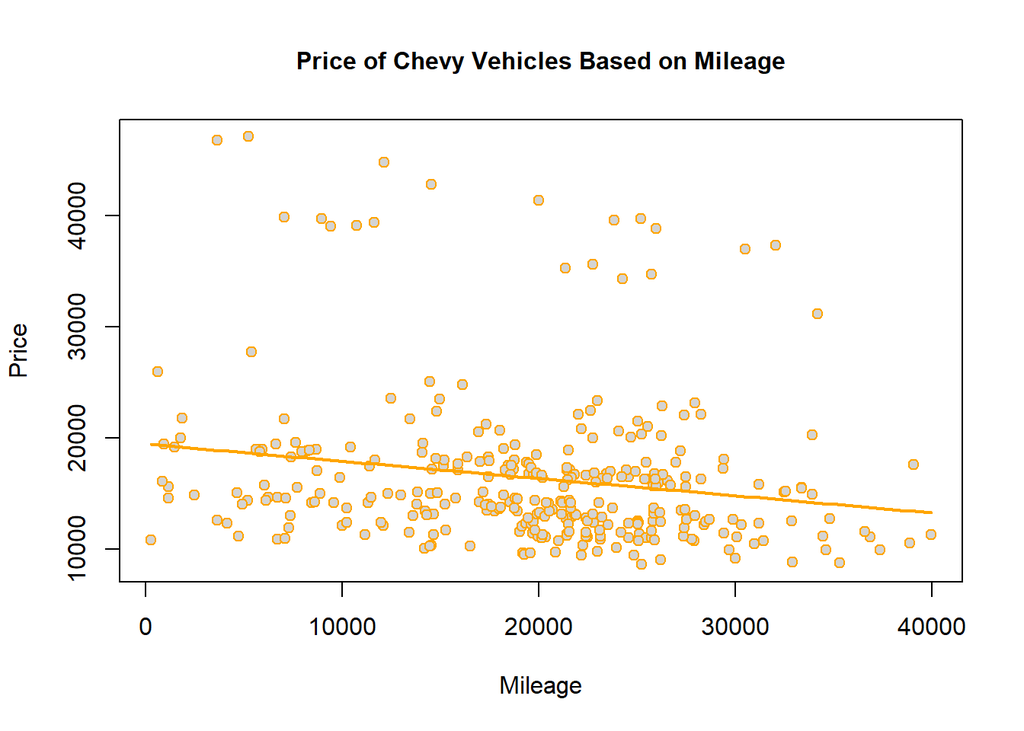

```r
Chevy_lm3 <- lm(Price ~ Mileage, data=Chevy)

plot(Price ~ Mileage, data=Chevy, col=c("orange"), pch=21, bg="gray83", main="Price of Chevy Vehicles Based on Mileage", cex.main=1)

#get the "Estimates" automatically:
b <- coef(Chevy_lm3)
# Then b will have 4 estimates:
# b[1] is the estimate of beta_0: -9.0099
# b[2] is the estimate of beta_1:  1.4385
# b[3] is the estimate of beta_2: -14.5107
# b[4] is the estimate of beta_3: 1.3214
curve(b[1] + b[2]*x, col="orange", lwd=2, add=TRUE)  #baseline (in blue)
```

```r
summary(Chevy_lm3) %>%
  pander()
```

|  | Estimate | Std. Error | t value | Pr(>\|t\|) |
| --- | --- | --- | --- | --- |
| **(Intercept)** | 19467 | 987.4 | 19.71 | 4.354e-57 |
| **Mileage** | -0.1547 | 0.04637 | -3.335 | 0.0009537 |

Fitting linear model: Price ~ Mileage

| Observations | Residual Std. Error | $R^2$ | Adjusted $R^2$ |
| --- | --- | --- | --- |
| 320 | 6794 | 0.03379 | 0.03076 |

My adjusted $R^2$ hardly dropped, which makes sense since leather did not have a significant p-value.

My final results show that leather was not a significant explanatory variable for the response variable. I did the scatterplot and summary of the regression without considering leather because leather wasn’t significantly affecting the starting price or depreciation rate of the Chevy vehicles.The only explanatory variable that was significant was the mileage, which makes sense. As we know, when you buy a car with low mileage, the price is higher than when you buy a car with high mileage. However, it is nice to be able to see this principle through an actual linear regression.

## The Limitations

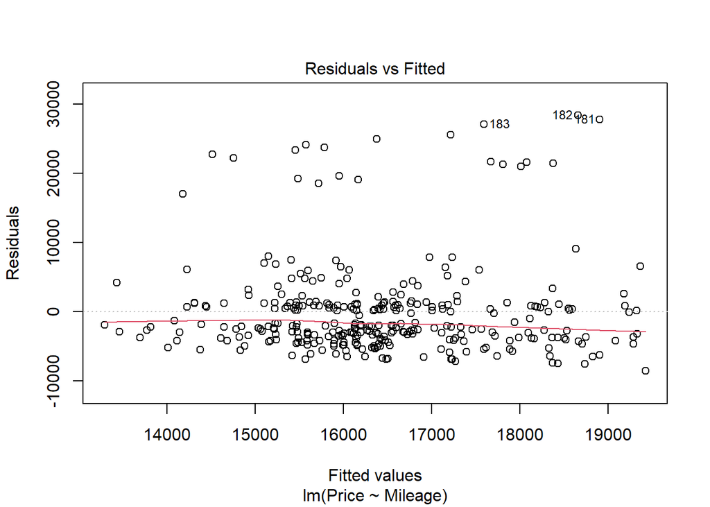

```r
plot(Chevy_lm3, which=1)
```

The residuals vs fitted-values plot checks to see if there is a linear relationship and if there is a constant variance. There seems to be no pattern at all. This means my linear relationship and constant variance assumptions look good.

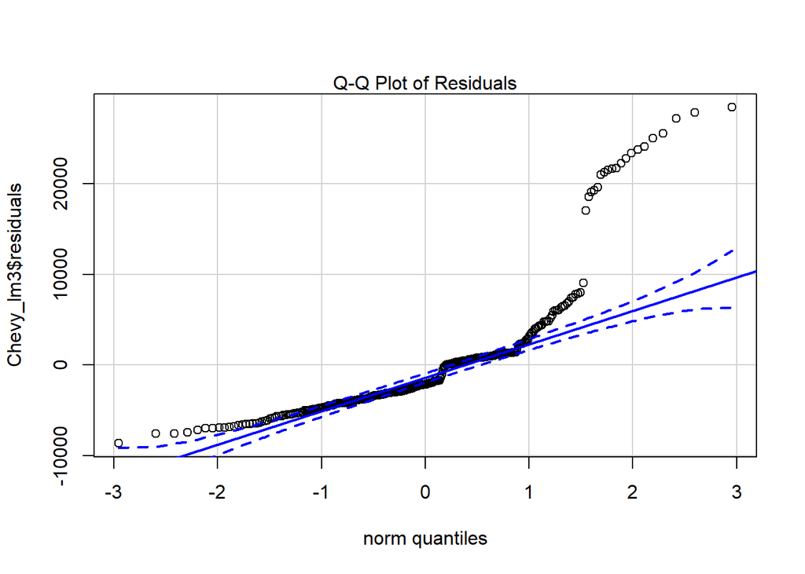

```r
qqPlot(Chevy_lm3$residuals, id=FALSE)
mtext(side=3,text="Q-Q Plot of Residuals")
```

The normality of the error terms is checked through the QQPlot. There are many points that are not within the dashed boundary lines. Since the residuals don’t look normal, then we can assume the error terms are not normal.

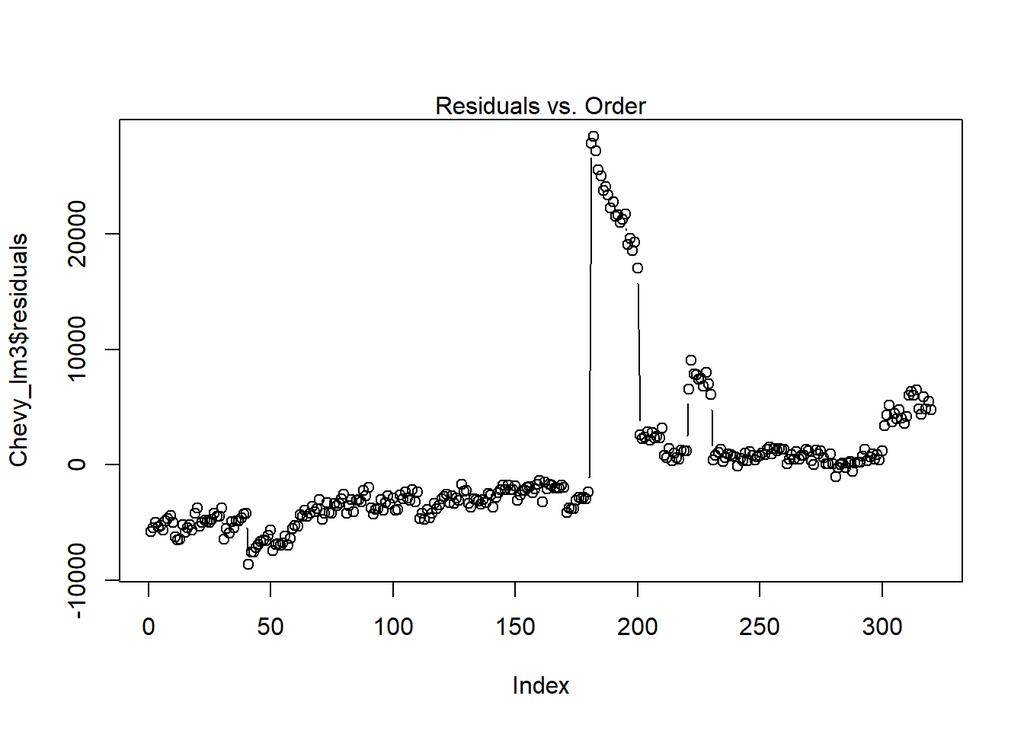

```r
plot(Chevy_lm3$residuals, type="b")
mtext(side=3, text="Residuals vs. Order")
```

The residuals vs order plot checks to see if the error terms are independent. In this case, there is a general trend. Therefore, it is questionable that the error terms are independent.